# R 고급 통계분석 2일차 (5)

Sanghoo Yoon

# 의사결정나무의 앙상블

앙상블(ensemble)은 여러 개의 모형을 만들어 각 모형의 예측을 다수결이나 평균하는 방법이다. 하나의 모형만을 학습시키는 것보다 대체로 나은 결과를 보여준다.

앙상블에는 배깅(bagging), 부스팅(boosting) 등의 방법이 있다.

## 배깅

배깅은 다음과 같이 한다. 먼저 데이터에서 일부를 샘플링 하는 부트스트랩(bootstrap)을 실시한다. 이렇게 만든 각각의 부트스트랩 샘플에 모형을 각각 학습시킨다. 그러면 하나의 데이터셋에서 여러 개의 샘플을 만들어 모형을 여러 번 학습시킬 수 있다. 이들의 예측을 합쳐 최종 예측을 한다. 배깅이라는 이름은 Bootstrap AGGregation에서 온 것이다.

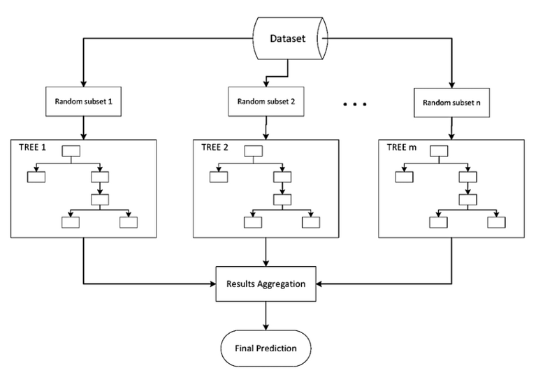

배깅은 의사결정나무와 같이 불안정한(unstable) 모형에 좋다. 반대로 안정한 모형의 경우에는 인위적으로 여러 샘플을 만들어 결과를 부정확하게 만들 수 있다.

### 랜덤 포레스트

랜덤 포레스트(random forest)는 의사결정나무에 배깅을 적용한 모형이다. 랜덤 포레스트에서 각각의 나무는 표준적인 배깅과 달리 무작위로 선택된 특성을 이용한다. 이를 특성 배깅(feature bagging)이라고 한다. 부트스트랩을 해서 샘플마다 차이가 있어도 예측력이 높은 특성이 있으면 모든 나무들이 같은 특성을 사용하기 때문에 앙상블을 하는 의의가 없다. 그래서 나무에서 사용할 특성을 무작위로 선택해서 다양한 나무를 만드는 것이다.

## 부스팅

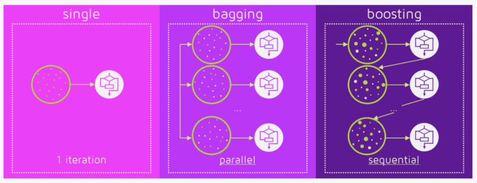

부스팅은 약한 학습 결과를 합쳐 강한 학습 결과를 만드는 방법이다.

최근에 각광을 받는 방법은 경사 부스팅(Gradient Boosting)이다. 경사 부스팅은 이전 학습 결과와 실제의 차이를 학습하는 방식이다. 예를 들어 첫번째 학습 결과 f1이 실제값 Y와 다음과 같은 관계가 있다고 해보자.

Y=f1(X)+ϵ1

여기서 ϵ1는 예측 오차이다. 이제 다시 두번째 학습 결과 f2가 이 예측 오차를 학습하게 한다. 그러면 다음과 같은 관계가 생긴다.

ϵ1=f2(X)+ϵ2

학습이 잘되었다면 첫번째 학습의 오차 분산 Var(ϵ1)보다 두번째 학습의 오차 분산 Var(ϵ2)가 더 줄어들게 된다.(결정계수 R2의 논리)

이제 두 번째 식을 첫 번째 식에 대입하면 다음과 같이 된다.

Y=f1(X)+f2(X)+ϵ2

이와 같은 과정을 반복하여 오차를 점점 줄여가는 방식이다. 아래 그림은 이를 도식화한 것이다. 왼쪽의 파란점은 실제값, 빨간 선은 예측값, 오른쪽의 초록색 점은 예측 오차를 나타낸다.

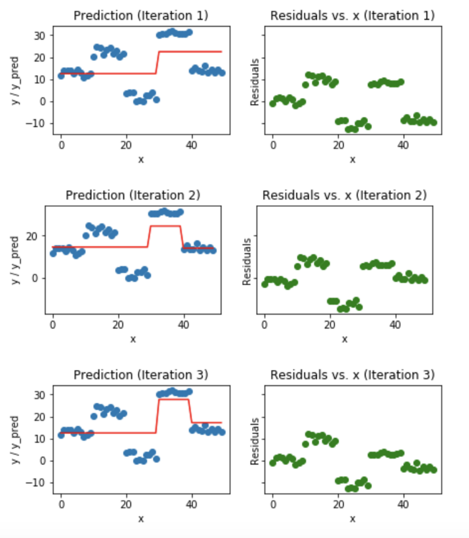

## R을 이용한 실습

UCI Machine Learning Repository의 Wine Quality 데이터를 연다

```r
red.url = 'https://archive.ics.uci.edu/ml/machine-learning-databases/wine-quality/winequality-red.csv'
white.url = 'https://archive.ics.uci.edu/ml/machine-learning-databases/wine-quality/winequality-white.csv'

red.wine = read.csv(url(red.url), sep = ';')
white.wine = read.csv(url(white.url), sep = ';')
```

데이터에 color라는 컬럼을 추가하고 와인 색상 값을 넣는다.

```r
red.wine$color = 'red'
white.wine$color = 'white'
```

레드 와인 데이터와 화이트 와인 데이터를 합쳐 wine이라는 하나의 데이터로 만든다.

```r
wine = rbind(red.wine, white.wine)
```

수업에서 결과를 일정하게 만들기 위해 난수의 시드 값을 고정한다.

caret 패키지를 불러들인다.

```r
set.seed(1234)
library(caret)
```

wine 데이터의 색상(color)를 기준으로 80%는 훈련용, 20%는 테스트용으로 데이터를 분할한다.

idx에 해당하는 행의 데이터는 data.train으로, 나머지 행의 데이터는 data.test로 분할한다.

```r
idx = createDataPartition(wine$color, p=.8, list=F)

data.train = wine[idx, ]
data.test = wine[-idx, ]
```

다른 패키지의 함수를 사용하셔도 괜찮습니다.

```r
library(tidymodels)
wine %>%
  initial_split(prop=0.8) -> wine_split
wine_split
```

```
## <Analysis/Assess/Total>
## <5198/1299/6497>
```

교차 검증 설정

```r
control = trainControl(method='repeatedcv', search='grid', number=5, repeats=10)
```

### 랜덤포레스트

랜덤 포레스트로 학습한다. 랜덤 포레스트의 하이퍼파라미터는 다음과 같다.

```
mtry: 각 트리를 만들 때 사용할 변수의 수
```

```r
rf.model = train(
  color ~ .,
  data = data.train,
  tuneGrid = data.frame(.mtry=c(4, 6, 8)),
  trControl = control,
  method = 'rf')

rf.model$results
```

```
##   mtry  Accuracy     Kappa  AccuracySD     KappaSD
## 1    4 0.9944028 0.9848400 0.002186963 0.005955306
## 2    6 0.9936334 0.9827567 0.002410327 0.006565317
## 3    8 0.9927486 0.9803596 0.002769892 0.007554629
```

성능평가

학습된 모형을 테스트 데이터에 적용해 색상을 예측한다.

```r
color.rf = predict(rf.model, data.test)
```

예측된 색상과 실제 색상을 비교하여 혼돈 행렬을 만들고 여러 가지 지표로 성능을 확인한다.

```r
confusionMatrix(color.rf, factor(data.test$color))
```

```
## Confusion Matrix and Statistics
##
##           Reference
## Prediction red white
##      red   313     1
##      white   6   978
##
##                Accuracy : 0.9946
##                  95% CI : (0.9889, 0.9978)
##     No Information Rate : 0.7542
##     P-Value [Acc > NIR] : <2e-16
##
##                   Kappa : 0.9854
##
##  Mcnemar's Test P-Value : 0.1306
##
##             Sensitivity : 0.9812
##             Specificity : 0.9990
##          Pos Pred Value : 0.9968
##          Neg Pred Value : 0.9939
##              Prevalence : 0.2458
##          Detection Rate : 0.2411
##    Detection Prevalence : 0.2419
##       Balanced Accuracy : 0.9901
##
##        'Positive' Class : red
##
```

변수중요도

```r
varImp(rf.model)
```

```
## rf variable importance
##
##                      Overall
## total.sulfur.dioxide 100.000
## chlorides             85.769
## volatile.acidity      36.928
## density               15.999
## fixed.acidity         13.827
## sulphates             13.777
## free.sulfur.dioxide   13.316
## residual.sugar        11.085
## pH                     5.825
## citric.acid            3.846
## alcohol                1.930
## quality                0.000
```

### XGBoost

XGBoost의 하이퍼파라미터는 아래와 같다.

```
nrounds: 최대 반복 횟수 (> 0)

eta 학습률. eta를 낮추면 모형의 과적합 가능성은 낮아지지만 학습 속도가 느려진다.(0 ~ 1)

gamma 트리에서 가지를 추가로 치기 위해 필요한 최소한의 손실 감소 기준. 기준값이 클 수록 모형이 더 단순해진다.(> 0)

max_depth 트리의 최대 깊이.(> 0)

min_child_weight 트리에서 가지를 추가로 치기 위해 필요한 최소한의 사례 수.(> 0)

colsample_bytree 각각의 트리를 만들 때 데이터에서 사용할 열(column)의 비율(0 ~ 1)
```

```r
xgb.grid = expand.grid(
  .nrounds = 100,
  .eta = c(0.1, 0.3, 0.5),
  .gamma = 1,
  .max_depth = c(3, 5),
  .min_child_weight = 1,
  .colsample_bytree = 1,
  .subsample=0.7
)

xgb.grid
```

```
##   .nrounds .eta .gamma .max_depth .min_child_weight .colsample_bytree
## 1      100  0.1      1          3                 1                 1
## 2      100  0.3      1          3                 1                 1
## 3      100  0.5      1          3                 1                 1
## 4      100  0.1      1          5                 1                 1
## 5      100  0.3      1          5                 1                 1
## 6      100  0.5      1          5                 1                 1
##   .subsample
## 1        0.7
## 2        0.7
## 3        0.7
## 4        0.7
## 5        0.7
## 6        0.7
```

경사 부스팅 모형을 학습시킨다.

```r
xgb.model <- train(
    color ~ .,
    data = data.train,
    tuneGrid = xgb.grid,
    trControl = control,
    method = 'xgbTree'
)
```

성능평가

학습된 모형을 테스트 데이터에 적용해 색상을 예측한다.

```r
color.xgb = predict(xgb.model, data.test)
```

예측된 색상과 실제 색상을 비교하여 혼돈 행렬을 만들고 여러 가지 지표로 성능을 확인한다.

```r
confusionMatrix(color.xgb, factor(data.test$color))
```

```
## Confusion Matrix and Statistics
##
##           Reference
## Prediction red white
##      red   313     2
##      white   6   977
##
##                Accuracy : 0.9938
##                  95% CI : (0.9879, 0.9973)
##     No Information Rate : 0.7542
##     P-Value [Acc > NIR] : <2e-16
##
##                   Kappa : 0.9833
##
##  Mcnemar's Test P-Value : 0.2888
##
##             Sensitivity : 0.9812
##             Specificity : 0.9980
##          Pos Pred Value : 0.9937
##          Neg Pred Value : 0.9939
##              Prevalence : 0.2458
##          Detection Rate : 0.2411
##    Detection Prevalence : 0.2427
##       Balanced Accuracy : 0.9896
##
##        'Positive' Class : red
##
```

```r
varImp(xgb.model)
```

```
## xgbTree variable importance
##
##                      Overall
## total.sulfur.dioxide 100.000
## chlorides             48.159
## volatile.acidity      12.261
## density                5.716
## sulphates              4.941
## pH                     4.140
## fixed.acidity          2.836
## residual.sugar         2.163
## alcohol                1.984
## citric.acid            1.590
## free.sulfur.dioxide    1.202
## quality                0.000
```

보다 자세한 내용은 https://topepo.github.io/caret/model-training-and-tuning.html